# Tugas Pertemuan 4

# Library

```r
library(ggplot2)
library(tsibble)
library(tseries)
library(MASS)
library(forecast)
library(TSA)
library(TTR)
library(aTSA)
library(graphics)
library(readxl)
```

# Data

```r
data <- read_xlsx("C:\\Dokumen\\Kuliah IPB\\Semester 5\\Metode Peramalan Deret Waktu\\Praktikum\\File R\\mpdw\\Pertemuan 6\\Data Suhu Rata-Rata Harian Malaysia.xlsx")
data.ts <- ts(data$Rata_Suhu)
data.ts
```

```
## Time Series:
## Start = 1
## End = 500
## Frequency = 1
##   [1] 28.4 28.6 28.9 28.4 27.9 28.9 28.2 28.5 27.4 28.3 28.2 28.3 28.9 28.2 28.3
##  [16] 28.6 28.2 27.2 27.8 28.9 27.6 28.0 27.5 27.5 28.1 29.8 27.8 27.7 28.2 27.8
##  [31] 28.2 28.5 25.5 28.2 26.6 26.2 27.7 28.1 27.8 26.7 28.5 27.5 28.9 27.2 26.7
##  [46] 28.4 26.5 26.8 27.0 27.5 27.4 28.1 27.5 26.9 26.4 27.8 25.5 27.2 27.4 26.5
##  [61] 27.0 25.4 26.9 27.7 28.2 27.5 25.8 27.4 27.1 26.9 27.5 28.2 27.1 27.0 27.6
##  [76] 27.9 27.6 27.7 27.8 26.9 27.8 27.7 26.2 27.5 27.7 27.0 26.5 25.7 26.2 27.2
##  [91] 26.8 26.1 26.7 26.9 26.9 27.9 26.6 26.7 26.7 26.9 26.8 26.1 26.9 26.3 27.1
## [106] 28.0 26.6 26.4 27.3 27.4 27.4 26.7 26.4 26.6 27.8 25.6 27.6 27.5 28.3 27.4
## [121] 28.4 28.0 27.7 27.7 28.0 26.8 26.6 27.2 27.6 27.5 27.5 26.5 27.5 27.1 27.7
## [136] 27.0 27.8 27.1 27.9 27.8 27.4 27.8 27.8 27.0 26.2 26.2 26.7 27.6 26.3 26.9
## [151] 27.3 27.2 27.3 26.2 25.3 26.7 27.5 27.8 27.2 26.4 27.6 27.4 27.1 26.3 27.4
```

[output cut: 23 more lines]

# Eksplorasi Data

## Plot Data Penuh

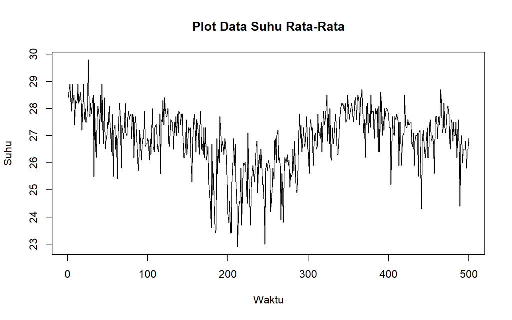

```r
plot.ts(data.ts,
        lty = 1,
        xlab = "Waktu",
        ylab = "Suhu",
        main = "Plot Data Suhu Rata-Rata")
```

Pembagian data latih dan data uji ditetapkan dengan proporsi 80%:20%.

## Plot Data Latih

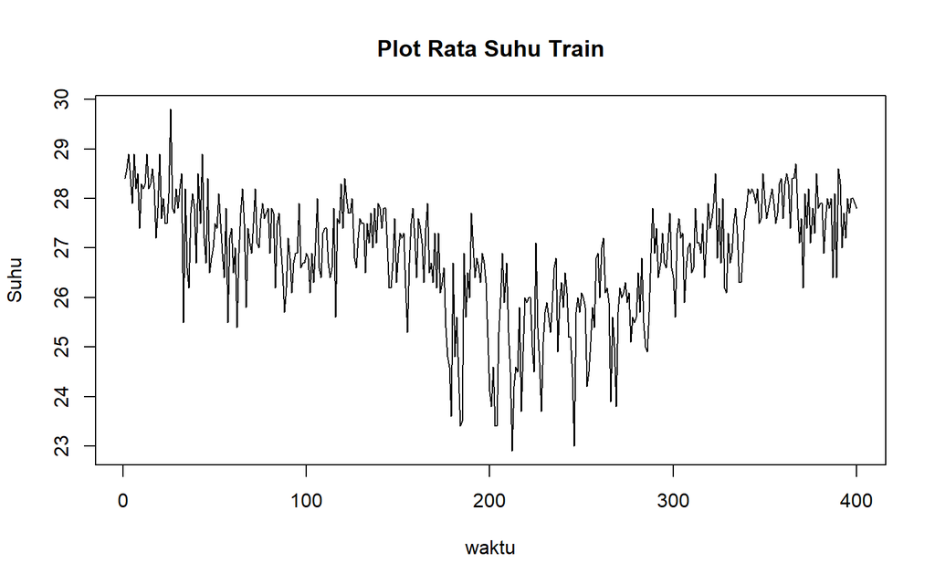

```r
data.train<-data[1:400,]
train.ts<-ts(data.train$Rata_Suhu)
plot.ts(train.ts, lty=1, xlab="waktu", ylab="Suhu", main="Plot Rata Suhu Train")
```

## Plot Data Uji

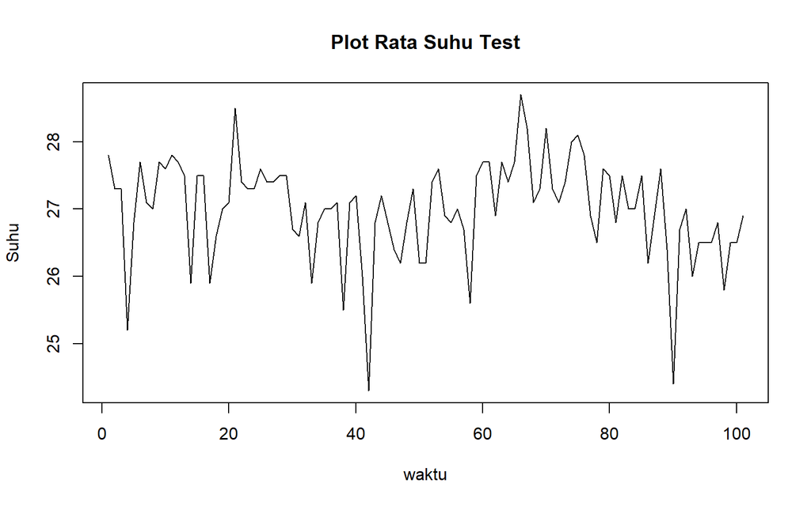

```r
data.test<-data[400:500,]
test.ts<-ts(data.test$Rata_Suhu)
plot.ts(test.ts, lty=1, xlab="waktu", ylab="Suhu", main="Plot Rata Suhu Test")
```

# Uji Stasioneritas

## Plot ACF

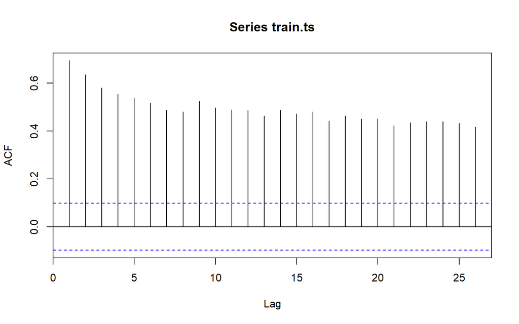

```r
acf(train.ts)
```

Plot ACF terlihat menurun secara perlahan (tails off). Hal ini mengindikasikan data tidak stasioner dalam rataan.

## Uji ADF

```r
tseries::adf.test(train.ts)
```

```
##
##  Augmented Dickey-Fuller Test
##
## data:  train.ts
## Dickey-Fuller = -2.958, Lag order = 7, p-value = 0.1727
## alternative hypothesis: stationary
```

$H_0:$ Data tidak stasioner dalam rataan $H_1:$ Data stasioner dalam rataan

Berdasarkan uji ADF, didapatkan p-value sebesar 0.1727 > 0.05 maka tak tolak H0. Maka data tidak stasioner dalam rataan.

## Plot Box Cox

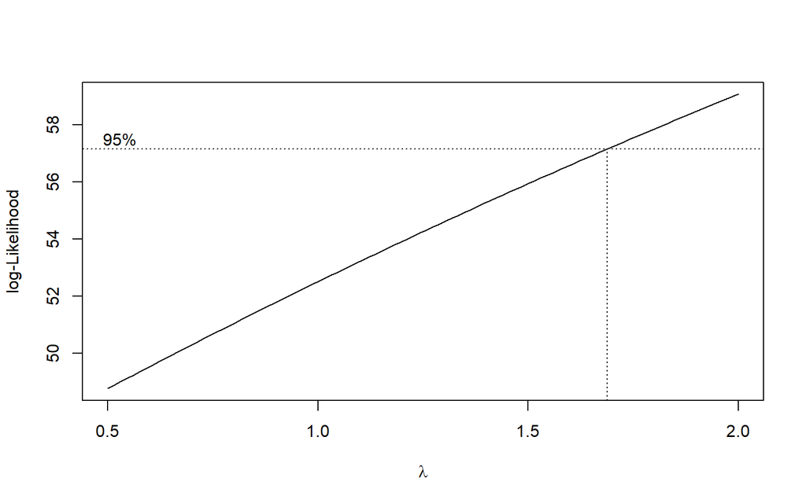

```r
index <- seq(1:400)

# Box-Cox
bc <- boxcox(train.ts ~ index, lambda = seq(0.5, 2, by = 0.1))
```

```r
# Nilai lambda optimum (rounded)
lambda_opt <- bc$x[which.max(bc$y)]
lambda_opt
```

```
## [1] 2
```

```r
# Selang kepercayaan 95% untuk lambda
ci_lambda <- bc$x[bc$y > max(bc$y) - 0.5 * qchisq(0.95, df = 1)]

# Batas bawah dan batas atas
ci_lower <- min(ci_lambda)
ci_upper <- max(ci_lambda)

c(Batas_Bawah = ci_lower, Batas_Atas = ci_upper)
```

```
## Batas_Bawah  Batas_Atas
##     1.69697     2.00000
```

Selang kepercayaan berada pada 1.69697 hingga 2 dan tidak memuat angka 1. Maka data tidak stasioner dalam ragam.

# Penanganan Ketidakstasioneran Data

## Penanganan Ketidakstasioneran dalam rataan

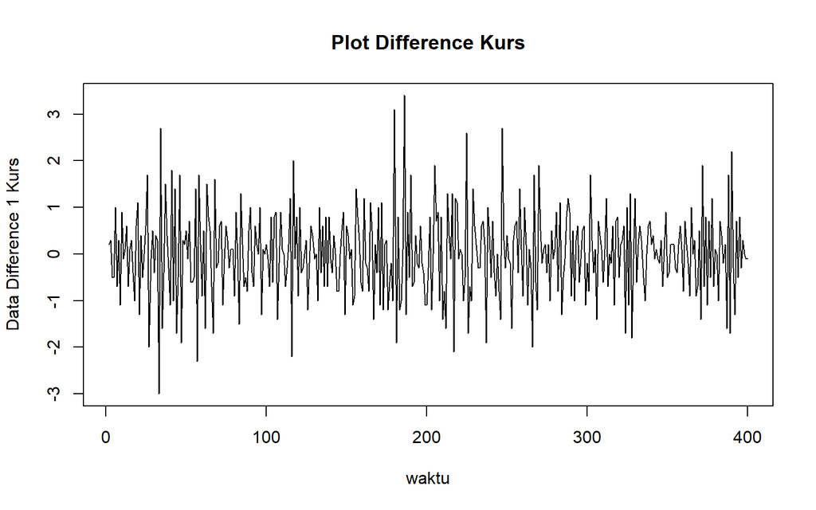

```r
# Dufferencing pertama
train.diff<-diff(train.ts,differences = 1)

# Plot hasil differencing
plot.ts(train.diff, lty=1, xlab="waktu", ylab="Data Difference 1 Kurs", main="Plot Difference Kurs")
```

Berdasarkan plot deret waktu, terlihat bahwa data bergerak pada nilai tengah tertentu dan tidak memiliki pola tren. Hal ini menunjukkan bahwa data stasioner dalam rataan.

## Plot ACF

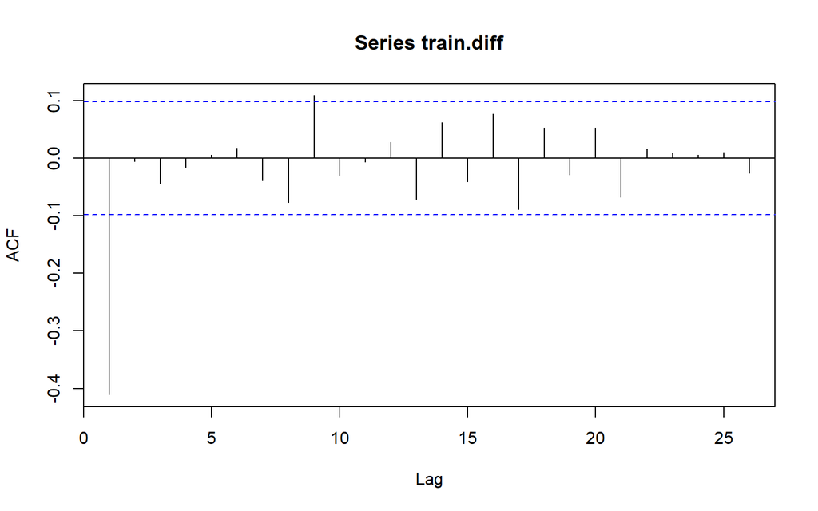

```r
acf(train.diff)
```

Plot ACF menunjukkan cut off pada lag ke-1 yang menandakan data sudah stasioner dalam rataan dan ketidakstasioneran sudah tertangani.

## Uji ADF

```r
tseries::adf.test(train.diff)
```

```
##
##  Augmented Dickey-Fuller Test
##
## data:  train.diff
## Dickey-Fuller = -11.488, Lag order = 7, p-value = 0.01
## alternative hypothesis: stationary
```

$H_0:$ Data tidak stasioner dalam rataan $H_1:$ Data stasioner dalam rataan

Berdasarkan uji ADF, didapatkan p-value sebesar 0.01 < 0.05 maka tolak H0. Maka data stasioner dalam rataan. Hal ini menunjukkan bahwa ketidakstasioneran dalam rataan berhasil ditangani.

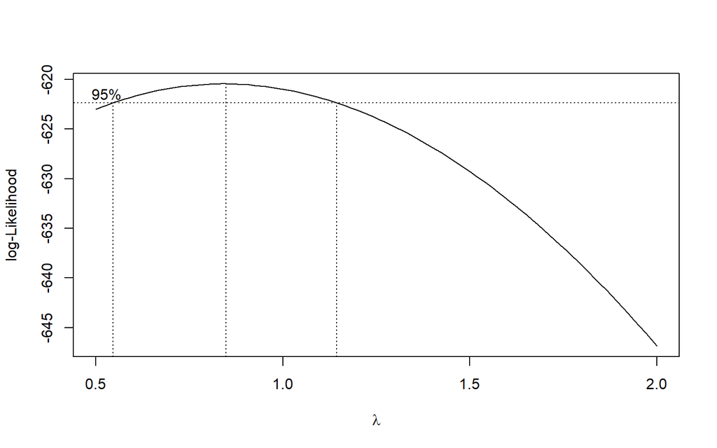

```r
# 1. Sesuaikan panjang index karena differencing menghilangkan 1 observasi awal
index_diff <- seq(1:length(train.diff))

# 2. Cek apakah ada nilai negatif/nol. Jika ada, tambahkan konstanta (c)
# agar nilai minimum data menjadi > 0 (misalnya menjadi 1)
min_val <- min(train.diff)

if (min_val <= 0) {
  c <- abs(min_val) + 1
  train.diff_shifted <- train.diff + c
} else {
  train.diff_shifted <- train.diff
}

# 3. Plot Box-Cox pada data yang sudah di-shift
bc_diff <- boxcox(train.diff_shifted ~ index_diff, lambda = seq(0.5, 2, by = 0.1))
```

```r
# 4. Nilai lambda optimum (rounded)
lambda_opt_diff <- bc_diff$x[which.max(bc_diff$y)]
print(paste("Lambda optimum setelah diff:", lambda_opt_diff))
```

```
## [1] "Lambda optimum setelah diff: 0.848484848484849"
```

```r
# 5. Selang kepercayaan 95% untuk lambda
ci_lambda_diff <- bc_diff$x[bc_diff$y > max(bc_diff$y) - 0.5 * qchisq(0.95, df = 1)]

# Batas bawah dan batas atas
ci_lower_diff <- min(ci_lambda_diff)
ci_upper_diff <- max(ci_lambda_diff)

c(Batas_Bawah = ci_lower_diff, Batas_Atas = ci_upper_diff)
```

```
## Batas_Bawah  Batas_Atas
##   0.5606061   1.1363636
```

Selang kepercayaan 95% berada pada 0.5606061 hingga 1.1363636. Selang tersebut memuat angka 1 sehingga bisa dikatakan bahwa data stasioner dalam ragam.

# Identifikasi Model

## Plot ACF

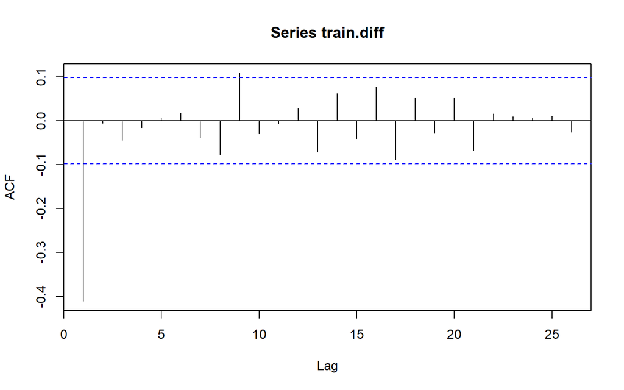

```r
acf(train.diff)
```

Plot ACF cenderung cuts off pada lag ke 1, sehingga jika plot PACF dianggap tails of, maka model tentatifnya adalah ARIMA(0,1,1).

## Plot PACF

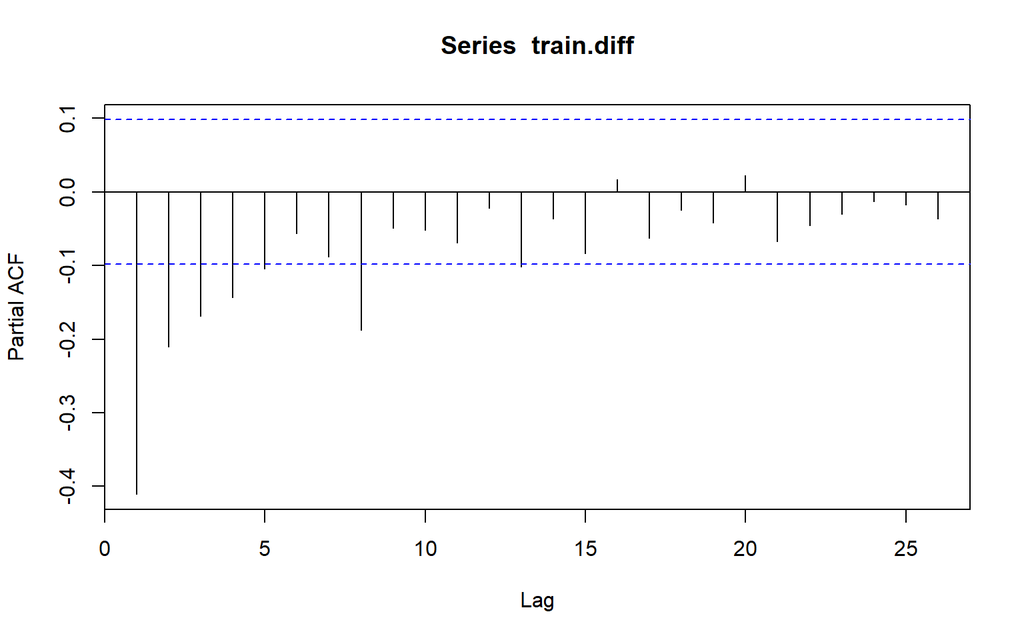

```r
pacf(train.diff)
```

Plot PACF cenderung cut off pada lag ke-5, sehingga jika plot ACF tail off maka model tentatifnya adalah ARIMA(5,1,0).

Jika Plot ACF dan PACF keduanya tail off maka model tentatifnya adalah ARIMA (1,1,1).

## Plot EACF

```r
eacf(train.diff)
```

```
## AR/MA
##   0 1 2 3 4 5 6 7 8 9 10 11 12 13
## 0 x o o o o o o o x o o  o  o  o
## 1 x o o o o o o o x o o  o  o  o
## 2 x o o o o o o o o o o  o  o  o
## 3 x x o o o o o o o o o  o  o  o
## 4 x x x o o o o o o o o  o  o  o
## 5 x x x x o x o o o o o  o  o  o
## 6 x o x o o o o o o o o  o  o  o
## 7 x o x x x x x o o o o  o  o  o
```

Identifikasi model menggunakan plot EACF dilakukan dengan melihat ujung segitiga pada pola segitiga nol. Dalam hal ini model tentatif yang terbentuk adalah ARIMA(2,1,1), ARIMA(1,1,2), ARIMA(2,1,2), dan ARIMA (3,1,2).

# Pendugaan Parameter Model Tentatif

## ARIMA (0,1,1)

```r
model1.da=Arima(train.diff, order=c(0,0,1),method="ML")
summary(model1.da)
```

```
## Series: train.diff
## ARIMA(0,0,1) with non-zero mean
##
## Coefficients:
##           ma1     mean
##       -0.7048  -0.0016
## s.e.   0.0566   0.0118
##
## sigma^2 = 0.6344:  log likelihood = -474.7
## AIC=955.41   AICc=955.47   BIC=967.37
##
## Training set error measures:
##                        ME      RMSE       MAE MPE MAPE      MASE      ACF1
## Training set 3.407054e-05 0.7944803 0.6213739 NaN  Inf 0.5207555 0.1058084
```

```r
lmtest::coeftest(model1.da)
```

```
##
## z test of coefficients:
##
##             Estimate Std. Error  z value Pr(>|z|)
## ma1       -0.7047727  0.0566055 -12.4506   <2e-16 ***
## intercept -0.0016255  0.0118133  -0.1376   0.8906
## ---
## Signif. codes:  0 '***' 0.001 '**' 0.01 '*' 0.05 '.' 0.1 ' ' 1
```

## ARIMA (5,1,0)

```r
model2.da=Arima(train.diff, order=c(5,0,0),method="ML")
summary(model2.da)
```

```
## Series: train.diff
## ARIMA(5,0,0) with non-zero mean
##
## Coefficients:
##           ar1      ar2      ar3      ar4      ar5     mean
##       -0.5701  -0.3598  -0.2777  -0.1994  -0.1033  -0.0016
## s.e.   0.0498   0.0565   0.0575   0.0563   0.0496   0.0160
##
## sigma^2 = 0.646:  log likelihood = -476.21
## AIC=966.42   AICc=966.7   BIC=994.34
##
## Training set error measures:
##                        ME      RMSE       MAE MPE MAPE      MASE         ACF1
## Training set 0.0002751034 0.7976762 0.6287172 NaN  Inf 0.5269097 -0.007091307
```

```r
lmtest::coeftest(model2.da)
```

```
##
## z test of coefficients:
##
##             Estimate Std. Error  z value  Pr(>|z|)
## ar1       -0.5701196  0.0497735 -11.4543 < 2.2e-16 ***
## ar2       -0.3598090  0.0564638  -6.3724 1.861e-10 ***
## ar3       -0.2777356  0.0575179  -4.8287 1.374e-06 ***
## ar4       -0.1994446  0.0563237  -3.5410 0.0003985 ***
## ar5       -0.1032680  0.0495955  -2.0822 0.0373236 *
## intercept -0.0015749  0.0159625  -0.0987 0.9214068
## ---
## Signif. codes:  0 '***' 0.001 '**' 0.01 '*' 0.05 '.' 0.1 ' ' 1
```

## ARIMA(2,1,1)

```r
model3.da=Arima(train.diff, order=c(2,0,1),method="ML")
summary(model3.da)
```

```
## Series: train.diff
## ARIMA(2,0,1) with non-zero mean
##
## Coefficients:
##          ar1     ar2      ma1     mean
##       0.2755  0.1059  -0.9089  -0.0014
## s.e.  0.0561  0.0542   0.0244   0.0059
##
## sigma^2 = 0.6065:  log likelihood = -464.91
## AIC=939.82   AICc=939.97   BIC=959.77
##
## Training set error measures:
##                        ME      RMSE       MAE MPE MAPE      MASE         ACF1
## Training set -0.002145704 0.7748691 0.6079101 NaN  Inf 0.5094719 -0.001351953
```

```r
lmtest::coeftest(model3.da)
```

```
##
## z test of coefficients:
##
##             Estimate Std. Error  z value  Pr(>|z|)
## ar1        0.2755157  0.0560676   4.9140 8.924e-07 ***
## ar2        0.1059023  0.0541553   1.9555   0.05052 .
## ma1       -0.9088904  0.0243719 -37.2925 < 2.2e-16 ***
## intercept -0.0014363  0.0058516  -0.2455   0.80610
## ---
## Signif. codes:  0 '***' 0.001 '**' 0.01 '*' 0.05 '.' 0.1 ' ' 1
```

## ARIMA(1,1,2)

```r
model4.da=Arima(train.diff, order=c(1,0,2),method="ML")
summary(model4.da)
```

```
## Series: train.diff
## ARIMA(1,0,2) with non-zero mean
##
## Coefficients:
##          ar1      ma1     ma2     mean
##       0.5727  -1.2002  0.2630  -0.0014
## s.e.  0.1354   0.1495  0.1286   0.0058
##
## sigma^2 = 0.6072:  log likelihood = -465.15
## AIC=940.29   AICc=940.45   BIC=960.24
##
## Training set error measures:
##                        ME      RMSE       MAE MPE MAPE      MASE         ACF1
## Training set -0.002244926 0.7753374 0.6076794 NaN  Inf 0.5092786 -0.007347374
```

```r
lmtest::coeftest(model4.da)
```

```
##
## z test of coefficients:
##
##             Estimate Std. Error z value  Pr(>|z|)
## ar1        0.5727306  0.1353857  4.2304 2.333e-05 ***
## ma1       -1.2002368  0.1495079 -8.0279 9.914e-16 ***
## ma2        0.2630058  0.1286068  2.0450   0.04085 *
## intercept -0.0014239  0.0058437 -0.2437   0.80749
## ---
## Signif. codes:  0 '***' 0.001 '**' 0.01 '*' 0.05 '.' 0.1 ' ' 1
```

## ARIMA(2,1,2)

```r
model5.da=Arima(train.diff, order=c(2,0,2),method="ML")
summary(model5.da)
```

```
## Series: train.diff
## ARIMA(2,0,2) with non-zero mean
##
## Coefficients:
##          ar1     ar2      ma1      ma2     mean
##       0.2589  0.1106  -0.8921  -0.0149  -0.0014
## s.e.  0.4868  0.1480   0.4892   0.4363   0.0059
##
## sigma^2 = 0.608:  log likelihood = -464.91
## AIC=941.82   AICc=942.03   BIC=965.75
##
## Training set error measures:
##                        ME      RMSE       MAE MPE MAPE      MASE         ACF1
## Training set -0.002156205 0.7748674 0.6079342 NaN  Inf 0.5094921 -0.001518265
```

```r
lmtest::coeftest(model5.da)
```

```
##
## z test of coefficients:
##
##             Estimate Std. Error z value Pr(>|z|)
## ar1        0.2589223  0.4867847  0.5319  0.59479
## ar2        0.1106414  0.1480183  0.7475  0.45477
## ma1       -0.8921397  0.4892362 -1.8235  0.06822 .
## ma2       -0.0149487  0.4362991 -0.0343  0.97267
## intercept -0.0014345  0.0058548 -0.2450  0.80644
## ---
## Signif. codes:  0 '***' 0.001 '**' 0.01 '*' 0.05 '.' 0.1 ' ' 1
```

## ARIMA(3,1,2)

```r
model6.da=Arima(train.diff, order=c(3,0,2),method="ML")
summary(model6.da)
```

```
## Series: train.diff
## ARIMA(3,0,2) with non-zero mean
##
## Coefficients:
```

```
##           ar1     ar2     ar3      ma1      ma2     mean
##       -0.2028  0.2376  0.0515  -0.4307  -0.4348  -0.0014
## s.e.      NaN     NaN     NaN      NaN      NaN   0.0059
##
## sigma^2 = 0.6096:  log likelihood = -464.91
## AIC=943.82   AICc=944.11   BIC=971.74
##
## Training set error measures:
##                       ME     RMSE       MAE MPE MAPE      MASE        ACF1
## Training set -0.00216506 0.774869 0.6079009 NaN  Inf 0.5094642 -0.00128576
```

```r
lmtest::coeftest(model6.da)
```

```
##
## z test of coefficients:
##
##             Estimate Std. Error z value Pr(>|z|)
## ar1       -0.2027598        NaN     NaN      NaN
## ar2        0.2375927        NaN     NaN      NaN
## ar3        0.0514907        NaN     NaN      NaN
## ma1       -0.4306763        NaN     NaN      NaN
## ma2       -0.4347714        NaN     NaN      NaN
## intercept -0.0014335  0.0058509  -0.245   0.8065
```

## ARIMA (1,1,1)

```r
model7.da=Arima(train.diff, order=c(1,0,1),method="ML")
summary(model5.da)
```

[output not shown]

```r
lmtest::coeftest(model7.da)
```

```
##
## z test of coefficients:
##
##             Estimate Std. Error  z value  Pr(>|z|)
## ar1        0.2790467  0.0595804   4.6835  2.82e-06 ***
## ma1       -0.8873273  0.0290994 -30.4930 < 2.2e-16 ***
## intercept -0.0015163  0.0062099  -0.2442    0.8071
## ---
## Signif. codes:  0 '***' 0.001 '**' 0.01 '*' 0.05 '.' 0.1 ' ' 1
```

# Ringkasan AIC

```r
model_tentatif <- data.frame(
  Model = c("ARIMA(0,1,1)","ARIMA(5,1,0)","ARIMA(2,1,1)", "ARIMA(1,1,2)",
            "ARIMA(2,1,2)", "ARIMA(3,1,2)", "ARIMA(1,1,1)"),
  AIC   = c(AIC(model1.da),AIC(model2.da), AIC(model3.da), AIC(model4.da), AIC(model5.da), AIC(model6.da), AIC(model7.da)),
  BIC   = c(BIC(model1.da),BIC(model2.da), BIC(model3.da), BIC(model4.da), BIC(model5.da), BIC(model6.da), BIC(model7.da))
)

model_tentatif
```

```
##          Model      AIC      BIC
## 1 ARIMA(0,1,1) 955.4060 967.3729
## 2 ARIMA(5,1,0) 966.4181 994.3409
## 3 ARIMA(2,1,1) 939.8209 959.7658
## 4 ARIMA(1,1,2) 940.2927 960.2375
## 5 ARIMA(2,1,2) 941.8199 965.7536
## 6 ARIMA(3,1,2) 943.8206 971.7434
## 7 ARIMA(1,1,1) 941.6209 957.5768
```